# Klasifikasi Kesuburan Tanah Menggunakan K-Nearest Neighbors (KNN) di KNIME

# Langkah 1: Memasukkan Excel Reader

Saya memasukkan node Excel Reader karena dataset yang digunakan berbentuk file Excel (.xlsx). Node ini diperlukan agar data bisa dibaca oleh KNIME dan dimasukkan ke dalam workflow.

Di dalam node Excel Reader, yang saya ubah adalah:

memilih file dataset Excel memilih sheet Dataset memastikan preview data muncul dengan benar

Penjelasan: Pada tahap ini saya membaca data awal ke dalam KNIME. Saya memilih file dataset kesuburan tanah, lalu memilih sheet Dataset karena data utama berada di sheet tersebut. Setelah itu saya mengecek apakah semua kolom sudah terbaca dengan benar.

[figure not shown]

Di dalam node Excel Reader, yang saya ubah adalah:

memilih file dataset Excel memilih sheet Dataset memastikan preview data muncul dengan benar.

[figure not shown]

Penjelasan: Pada tahap ini saya membaca data awal ke dalam KNIME. Saya memilih file dataset kesuburan tanah, lalu memilih sheet Dataset karena data utama berada di sheet tersebut. Setelah itu saya mengecek apakah semua kolom sudah terbaca dengan benar.

# Langkah 2: Memasukkan Column Filter

Saya memasukkan node Column Filter karena tidak semua kolom dalam dataset digunakan untuk proses klasifikasi. Ada kolom yang hanya berfungsi sebagai identitas data, yaitu kolom ID.

[figure not shown]

[figure not shown]

Nah bagian yg diubah di dalam Column Filter adalah :

kolom ID dikeluarkan kolom fitur tetap dipakai kolom Label tetap dipakai

**Penjelasan:** Column Filter digunakan untuk memilih kolom yang diperlukan dalam analisis. Kolom ID dibuang karena hanya sebagai nomor urut data dan tidak berpengaruh pada klasifikasi. Kolom fitur dan Label tetap dipertahankan karena digunakan dalam proses pembentukan model.

# Langkah 3. Table Partitioner

Alasan menggunakan Table Partitioner setelah Column Filter Setelah kolom yang tidak diperlukan dibuang menggunakan Column Filter, data yang tersisa adalah kolom-kolom yang benar-benar dipakai untuk proses klasifikasi. Pada tahap ini, data perlu dibagi menjadi data training dan data testing. Oleh karena itu, setelah Column Filter digunakan node Table Partitioner.

Node ini dipakai pada tahap ini karena model KNN tidak langsung dijalankan ke seluruh data sekaligus. Model harus terlebih dahulu belajar dari data training, lalu diuji menggunakan data testing. Jika data tidak dibagi, maka hasil evaluasi model tidak dapat menggambarkan performa model secara benar.

[figure not shown]

Yang diubah di dalam Table Partitioner

Pada node Table Partitioner, pengaturan yang diubah adalah:

Relative size = 80 Sampling strategy = Stratified Group column = Label

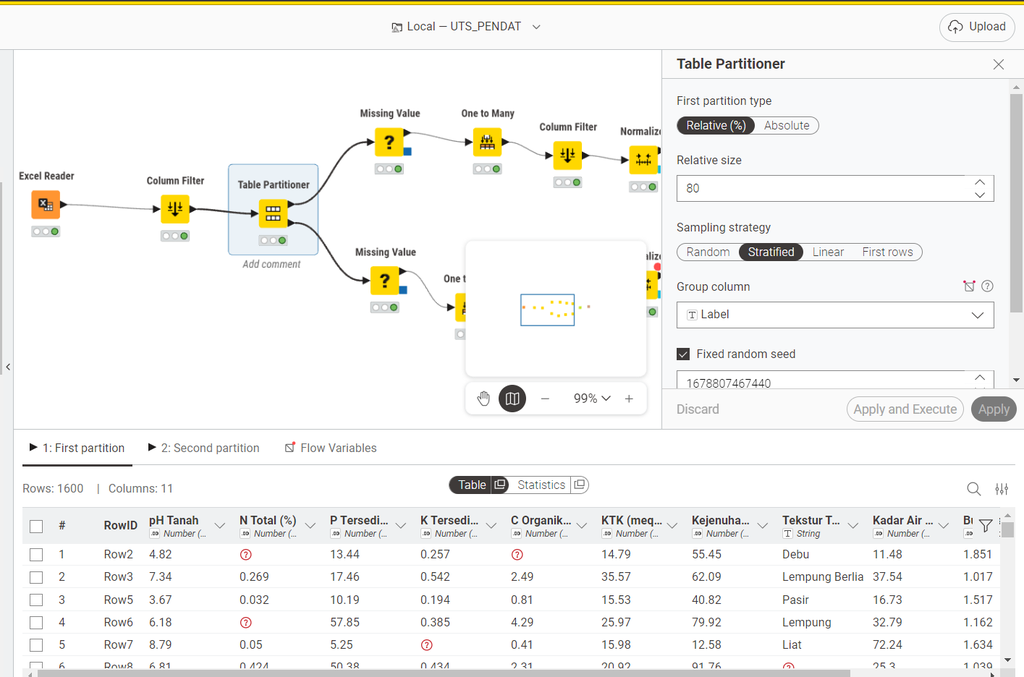

**Penjelasan**

Pengaturan Relative size = 80 digunakan agar 80% data masuk ke data training dan 20% sisanya menjadi data testing. Pembagian ini dipilih karena umum digunakan dalam klasifikasi, sehingga model memperoleh data latih yang cukup banyak, tetapi tetap memiliki data uji untuk evaluasi.

Pengaturan Sampling strategy = Stratified digunakan agar proporsi kelas Subur dan Tidak Subur tetap seimbang pada kedua bagian data. Sementara itu, Group column = Label dipilih karena kolom Label berisi kelas target yang harus dijaga distribusinya saat proses pembagian data.

Dengan langkah ini, data sudah siap diproses lebih lanjut pada cabang training dan testing secara terpisah.

# Langkah 4. Menangani Missing Value dengan Missing Value

Alasan menggunakan Missing Value setelah Table Partitioner Setelah data dibagi menggunakan Table Partitioner, data keluar menjadi dua cabang. Cabang atas digunakan sebagai data training, yaitu data yang dipakai untuk melatih model KNN. Cabang bawah digunakan sebagai data testing, yaitu data yang dipakai untuk menguji hasil model. Karena pada kedua cabang tersebut masih terdapat beberapa nilai kosong, maka setelah Table Partitioner digunakan node Missing Value.

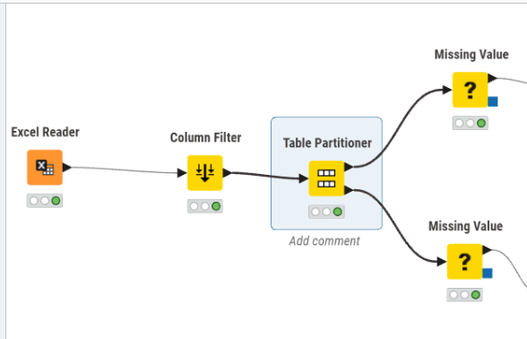

Yang diubah di dalam Missing Value

Pada node Missing Value, pengaturan yang diubah adalah:

Number (Float) = Mean String = Most Frequent Value

[figure not shown]

# Penjelasan

Pada cabang atas, node Missing Value digunakan untuk membersihkan data training dari nilai kosong agar data latih siap dipakai dalam proses pembelajaran model. Pada cabang bawah, node Missing Value digunakan untuk membersihkan data testing agar data uji juga siap diproses saat model melakukan prediksi.

Pengaturan Mean dipakai untuk mengisi nilai kosong pada kolom numerik dengan nilai rata-rata, sedangkan Most Frequent Value dipakai untuk mengisi nilai kosong pada kolom string dengan nilai yang paling sering muncul. Kedua cabang menggunakan pengaturan yang sama agar proses pembersihan data tetap konsisten.

# Langkah 5. One to Many

Penjelasan workflow dan fungsinya setelah workflow sebelumnya Setelah data pada cabang atas dan cabang bawah selesai dibersihkan menggunakan Missing Value, langkah berikutnya adalah mengubah kolom yang masih berbentuk kategorikal menjadi numerik. Oleh karena itu, setelah Missing Value digunakan node One to Many.

**Pada tahap ini:**

cabang atas berfungsi sebagai data training, sehingga One to Many digunakan untuk mengubah kolom Tekstur Tanah pada data training menjadi bentuk numerik cabang bawah berfungsi sebagai data testing, sehingga One to Many digunakan untuk mengubah kolom Tekstur Tanah pada data testing dengan cara yang sama

Node ini dipakai setelah Missing Value karena sebelum data diubah ke bentuk numerik, data harus lebih dulu dibersihkan dari nilai kosong. Dengan demikian, proses transformasi kategori ke numerik dapat berjalan dengan baik.

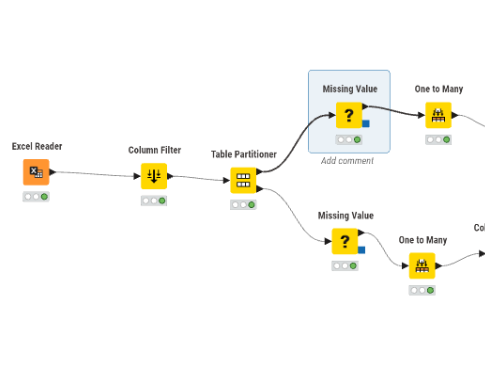

Pada node One to Many

**pengaturan yang diubah adalah:**

memilih kolom Tekstur Tanah

kolom Label tidak dipilih

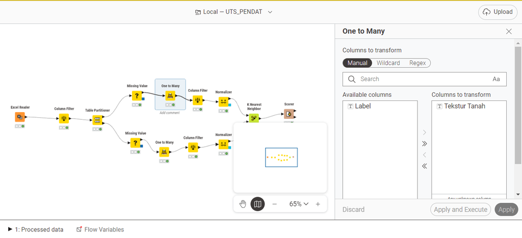

**Penjelasan :**

Kolom Tekstur Tanah dipilih karena kolom tersebut masih berbentuk teks atau kategori, sedangkan model KNN memerlukan fitur dalam bentuk numerik. Dengan One to Many, kolom Tekstur Tanah dipecah menjadi beberapa kolom dummy yang berisi nilai 0 dan 1.

Kolom Label tidak ikut dipilih karena kolom tersebut merupakan target klasifikasi. Jika Label ikut diubah, maka struktur kelas target akan berubah dan proses klasifikasi menjadi tidak sesuai.

Jadi, fungsi One to Many pada cabang atas adalah menyiapkan data training agar siap dipakai untuk melatih model, sedangkan pada cabang bawah berfungsi menyiapkan data testing agar formatnya sama dengan data training.

# Langkah 6. Column Filter setelah One to Many

Penjelasan workflow dan fungsinya setelah workflow sebelumnya :

Setelah proses One to Many selesai, data pada kedua cabang memang sudah memiliki kolom dummy numerik hasil transformasi. Namun, kolom Tekstur Tanah yang asli masih tetap ada dan masih berbentuk string. Karena model KNN hanya menerima fitur numerik, maka setelah One to Many digunakan kembali node Column Filter.

Pada tahap ini:

cabang atas berfungsi untuk membersihkan data training dari kolom string yang sudah tidak diperlukan cabang bawah berfungsi untuk membersihkan data testing dari kolom string yang sama agar susunan data testing tetap sama dengan data training

Node ini dipakai setelah One to Many karena kolom dummy baru sudah terbentuk, sehingga kolom string aslinya tidak lagi dibutuhkan.

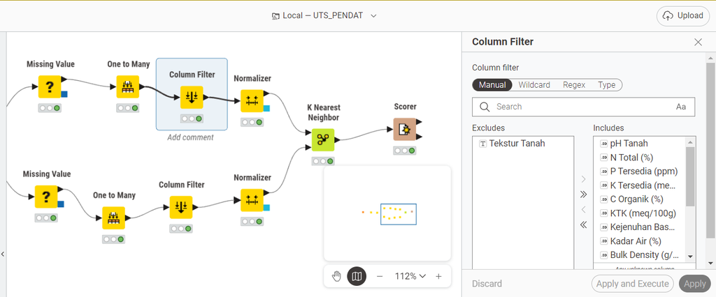

Pada node Column Filter, pengaturan yang diubah adalah:

kolom Tekstur Tanah asli dibuang

kolom dummy hasil One to Many tetap dipakai

kolom Label tetap dipakai

**Penjelasan:**

Kolom Tekstur Tanah asli dibuang karena masih bertipe string dan tidak bisa dipakai langsung oleh model KNN. Kolom tersebut juga sudah tidak diperlukan lagi karena informasinya sudah diwakili oleh kolom-kolom dummy hasil One to Many.

Kolom dummy hasil transformasi tetap dipertahankan karena kolom tersebut sudah berbentuk numerik dan nantinya dipakai sebagai fitur input model. Kolom Label juga tetap dipertahankan karena masih dibutuhkan sebagai target klasifikasi.

Dengan demikian, fungsi Column Filter pada cabang atas adalah membersihkan data training sebelum masuk ke proses normalisasi, sedangkan pada cabang bawah berfungsi membersihkan data testing dengan cara yang sama.

# Langkah 7. Normalizer

Penjelasan workflow dan fungsinya setelah workflow sebelumnya:

Setelah kolom string dibuang menggunakan Column Filter, seluruh fitur pada kedua cabang sudah berbentuk numerik. Tahap berikutnya adalah menyamakan skala data menggunakan Normalizer. Oleh karena itu, setelah Column Filter digunakan node Normalizer.

Pada tahap ini:

cabang atas berfungsi untuk menormalkan data training cabang bawah berfungsi untuk menormalkan data testing

Node ini digunakan karena model KNN bekerja dengan menghitung jarak antar data. Jika skala antar fitur terlalu berbeda, maka fitur dengan nilai lebih besar bisa lebih dominan dalam perhitungan jarak. Dengan normalisasi, setiap fitur dapat berkontribusi secara lebih seimbang.

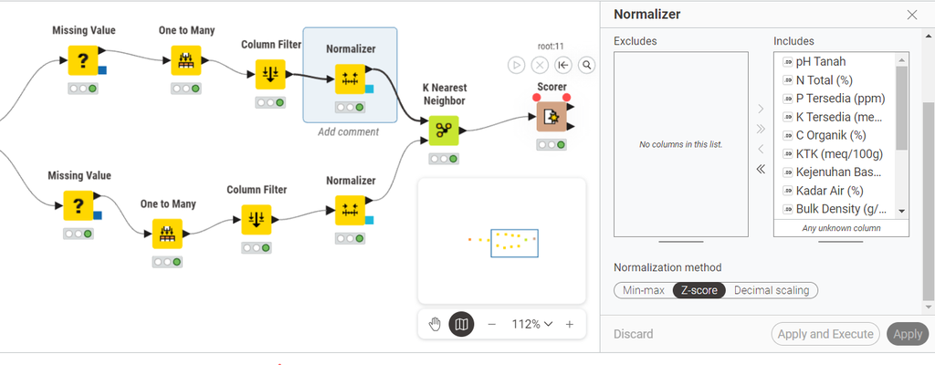

Pada node Normalizer, pengaturan yang diubah adalah:

metode Z-Score

kolom Label tidak ikut dinormalisasi

kolom RowID tidak ikut dinormalisasi

**Penjelasan :**

Metode Z-Score dipilih karena dapat menyamakan skala data berdasarkan rata-rata dan simpangan baku. Pengaturan ini cocok digunakan untuk KNN karena membantu model menghitung jarak dengan lebih adil antar fitur.

Kolom Label tidak ikut dinormalisasi karena kolom tersebut bukan fitur input, melainkan target klasifikasi. RowID juga tidak dinormalisasi karena hanya berfungsi sebagai identitas baris data.

Fungsi Normalizer pada cabang atas adalah menyiapkan data training agar model belajar dari data yang sudah memiliki skala seimbang. Sementara itu, fungsi Normalizer pada cabang bawah adalah menyiapkan data testing agar saat dibandingkan dengan data training, skala fitur tetap konsisten.

# Langkah 8. K Nearest Neighbor

Penjelasan workflow dan fungsinya setelah workflow sebelumnya:

Setelah data pada cabang atas dan cabang bawah selesai diproses sampai tahap Normalizer, data sudah siap digunakan untuk proses klasifikasi. Pada tahap ini, cabang atas berisi data training yang digunakan untuk melatih model, sedangkan cabang bawah berisi data testing yang digunakan untuk menguji model. Oleh karena itu, setelah Normalizer digunakan node K Nearest Neighbor.

Node K Nearest Neighbor dipakai pada tahap ini karena metode yang diminta dalam soal adalah metode K-Nearest Neighbors (KNN). Fungsi node ini adalah melakukan klasifikasi terhadap data testing dengan membandingkannya terhadap data training berdasarkan jarak antar data. Dengan kata lain, node ini akan menentukan apakah suatu data termasuk kelas Subur atau Tidak Subur berdasarkan tetangga terdekatnya.

[figure not shown]

Pada node K Nearest Neighbor, pengaturan yang diubah adalah:

Column with class labels = Label

Number of neighbours to consider = 5

**Penjelasan:** Kolom Label dipilih sebagai class labels karena kolom tersebut berisi kelas target yang akan diprediksi, yaitu Subur dan Tidak Subur. Pemilihan ini penting agar model mengetahui kolom mana yang menjadi acuan saat mempelajari pola dari data training.

Nilai k = 5 dipilih karena model akan menentukan kelas suatu data berdasarkan 5 tetangga terdekat. Nilai ini cukup umum digunakan pada metode KNN karena tidak terlalu kecil dan tidak terlalu besar, sehingga dapat menghasilkan klasifikasi yang lebih stabil.

Pada tahap ini, cabang atas berfungsi sebagai data latih yang menjadi dasar pembelajaran model, sedangkan cabang bawah berfungsi sebagai data uji yang akan diprediksi oleh model. Dengan demikian, hasil dari node K Nearest Neighbor adalah kolom prediksi kelas untuk data testing.

# Langkah 9. Scorer

Penjelasan workflow dan fungsinya setelah workflow sebelumnya:

Setelah model K Nearest Neighbor selesai menghasilkan prediksi terhadap data testing, langkah berikutnya adalah mengevaluasi hasil prediksi tersebut. Oleh karena itu, setelah K Nearest Neighbor digunakan node Scorer.

Fungsi node Scorer adalah membandingkan hasil prediksi model dengan label asli pada data testing. Dengan node ini, dapat diketahui seberapa baik performa model dalam mengklasifikasikan data. Node ini juga menghasilkan confusion matrix dan metrik evaluasi seperti Accuracy, Precision, Recall, dan F1-Score.

[figure not shown]

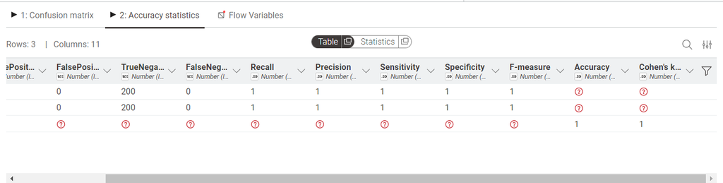

Pada node Scorer, pengaturan yang diubah adalah:

First column = Class [kNN]

Second column = Label

**Penjelasan:** Kolom Class [kNN] dipilih karena kolom ini merupakan hasil prediksi yang dihasilkan oleh model K Nearest Neighbor. Sementara itu, kolom Label dipilih karena kolom tersebut merupakan kelas asli pada data testing.

Dengan membandingkan kedua kolom tersebut, node Scorer dapat menunjukkan apakah prediksi model sudah sesuai dengan data sebenarnya. Dari proses ini dihasilkan confusion matrix, yaitu tabel yang menunjukkan jumlah prediksi benar dan salah pada masing-masing kelas. Selain itu, node ini juga menghitung nilai Accuracy, Precision, Recall, dan F1-Score sebagai ukuran performa model.

Dengan demikian, node Scorer berfungsi sebagai tahap akhir untuk menilai apakah model KNN yang dibuat sudah bekerja dengan baik atau belum.

Download Notebook (.ipynb) | [Open in Colab](https://colab.research.google.com/github/dapinfru/pendata/blob/main/UTS_PENDAT.ipynb)